# QAA

Lisa Adriani

2022-09-01

# Part 1

## 1.1

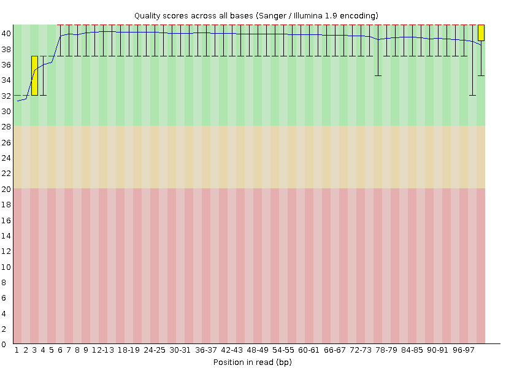

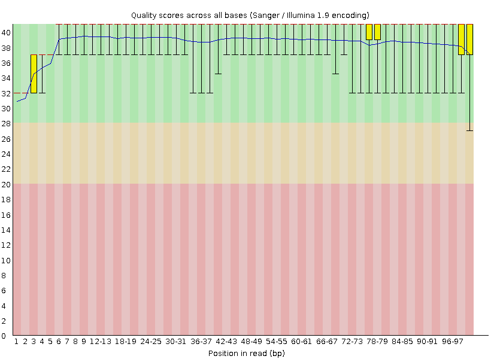

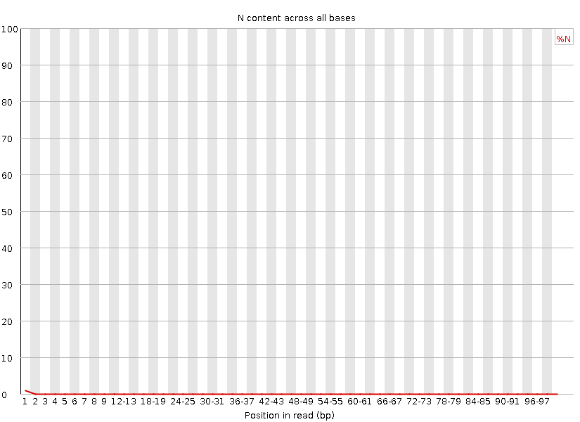

16.3D.mbnl.S12.L008 – Read 2 Quality Score and N Content

[figure not shown]

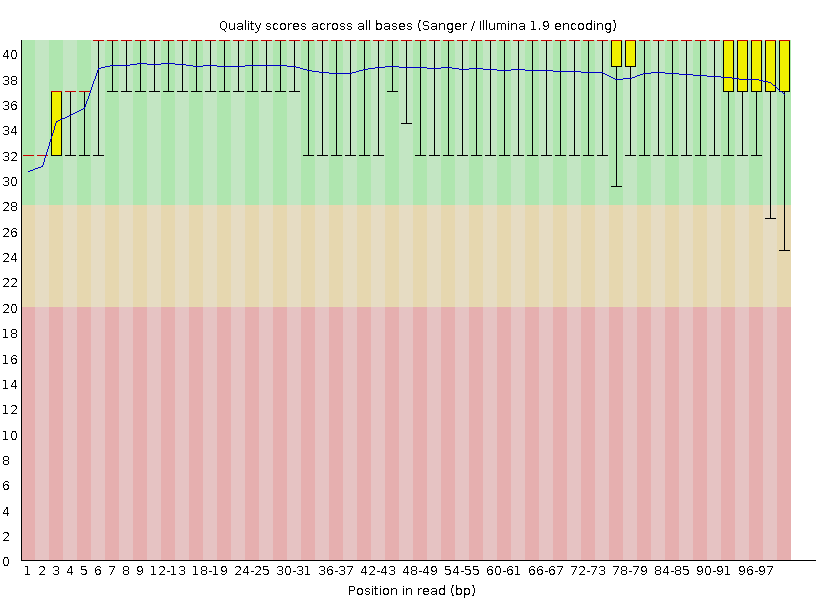

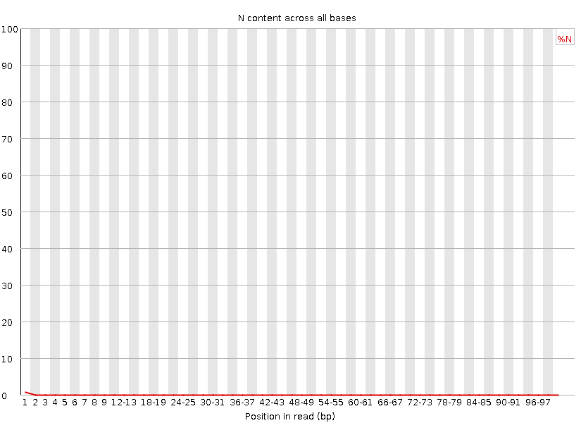

32.4G.both.S23 – Read 2 Quality Score and N Content

For each of these reads, we can see the greatest drop of Quality Score at the beginning of the sequence, in the first five bases or so. When compared to the N content, while there are a minimal amount of N’s, we can see the greatest number of N’s show up in the first position of the reads. Overall, the quality score is consistent with the N content of each of my reads.

## 1.2

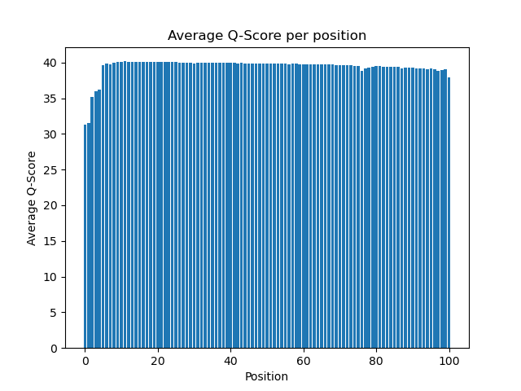

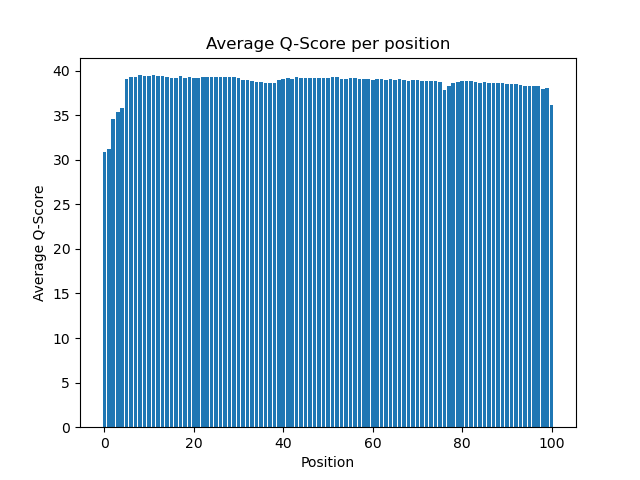

16.3D.mbnl.S12.L008 – Read 1 and Read 2 Quality Score Distribution from Demultiplex

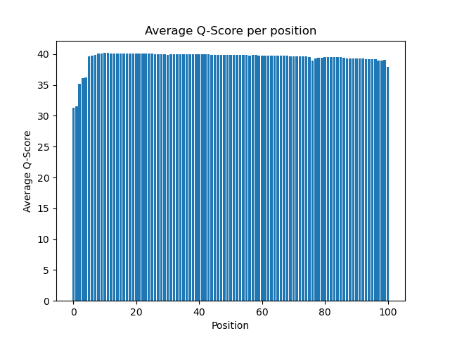

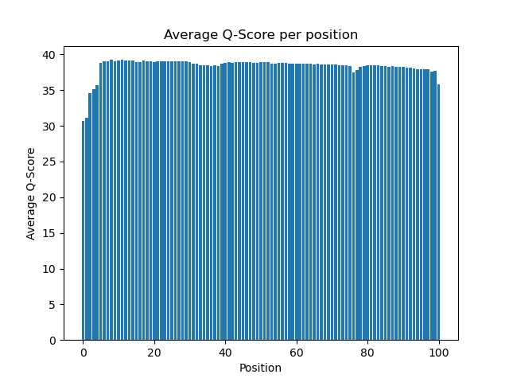

32.4G.both.S23 – Read 1 and Read 2 Quality Score Distribution from Demultiplex

The differences between the quality per position graphs of FastQC and the Demultiplex Assignment at first glance extremely different because the FastQC data has error bars, which the Demultiplex graphs do not. Overall, the graphs show similar trends within samples, but the variance information leads the FastQC graphs to be much more useful. FastQC was also able to run QC analyses and return graphed data for all four zipped files in just under 4 minutes, while my Demultiplex histogram code needed 3.5-5 minutes *per* file, just in order to calculate and graph the average Quality Score. First off, FastQC was not written by a new bioinformatics student, and I’m sure I do not have the most elegant code. To add to that, FastQC is written in java, which is a compiled program language, which typically runs in a more efficient manner than Python.

## 1.3

# Part 2

## 2.5

From the cutadapt output for 16.3D.mbnl.S12.L008, I can see that 12.2% of Read 1 was trimmed and 13% of read 2 was trimmed.

Read 1 with adapter: 1,002,983 (12.2%)

Read 2 with adapter: 1,069,893 (13.0%)

From the cutadapt output for 32.4G.both.S23, I can see that 5.3% of Read 1 was trimmed and 6.1% of Read 2 was trimmed.

Read 1 with adapter: 631,720 (5.3%)

Read 2 with adapter: 725,571 (6.1%)

## 2.5 Sanity Check:

I checked to make sure that there were no longer adapter sequences by using a grep command:

```r
 cat output_16.R1.fastq | grep "AGATCGGAAGAGCGTCGTGTAGGGAAAGAGTGT"
 cat output_16.R2.fastq | grep "AGATCGGAAGAGCGTCGTGTAGGGAAAGAGTGT"
 cat output_16.R1.fastq | grep "AGATCGGAAGAGCACACGTCTGAACTCCAGTCA"
 cat output_16.R2.fastq | grep "AGATCGGAAGAGCACACGTCTGAACTCCAGTCA"
 cat output_32.R2.fastq | grep "AGATCGGAAGAGCGTCGTGTAGGGAAAGAGTGT"
 cat output_32.R1.fastq | grep "AGATCGGAAGAGCGTCGTGTAGGGAAAGAGTGT"
 cat output_32.R1.fastq | grep "AGATCGGAAGAGCACACGTCTGAACTCCAGTCA"
 cat output_32.R2.fastq | grep "AGATCGGAAGAGCACACGTCTGAACTCCAGTCA"
```

This grep command created no output, so I know that these adaptor sequences were pulled from the data. I double checked that they were in the oriignal sequences by running the same commands (with zcat instead) on the files given to me.

## 2.7

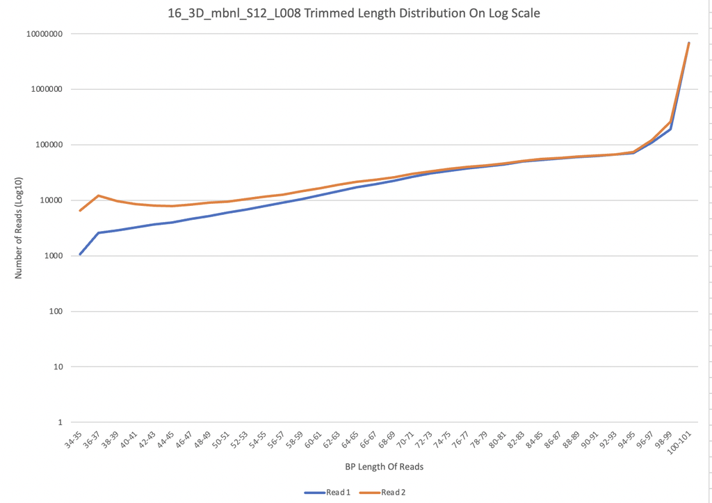

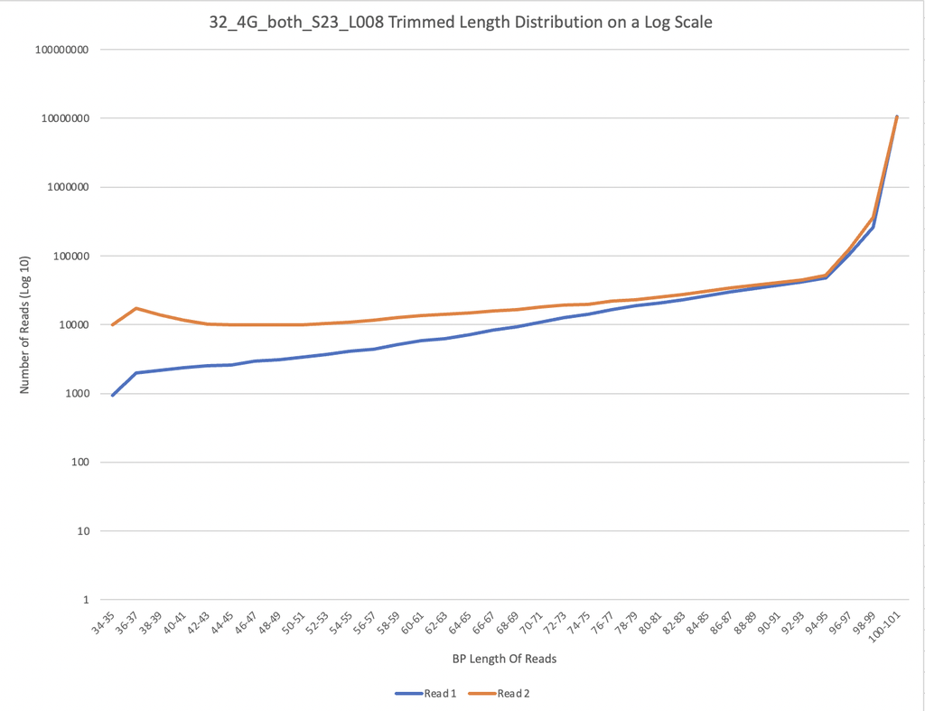

Trimmed Length Distribution on a Log Scale

I would expect Read 2’s to be trimmed at a higher rate than Read 1. We can expect the best sequencing to occur at the beginning of the reaction, because by the end of Read 2, the samples have been on the sequencer for an incredibly long time, and the reagents may start to degrade or bind to the incorrect positions on the insert. If we look at Figure 7, this looks like it is what happened, as there are slightly higher rates of trimming in both Read 2’s rather than Read 1’s.

# Part 3

## 3.12

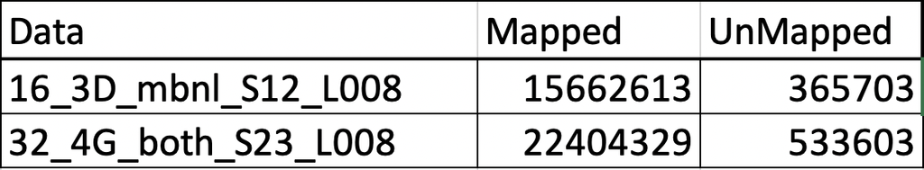

Table of output from map.py: Mapped VS Unmapped reads

```r
htmltools::includeHTML("qc_out/16_3D_mbnl_S12_L008_R1_001_fastqc.html")
```

FastQC Report

Thu 4 Aug 2022  
16_3D_mbnl_S12_L008_R1_001.fastq.gz

## Summary

- Basic Statistics
- Per base sequence quality
- Per tile sequence quality
- Per sequence quality scores
- Per base sequence content
- Per sequence GC content
- Per base N content
- Sequence Length Distribution
- Sequence Duplication Levels
- Overrepresented sequences
- Adapter Content

## Basic Statistics

| Measure | Value |
| --- | --- |
| Filename | 16_3D_mbnl_S12_L008_R1_001.fastq.gz |
| File type | Conventional base calls |
| Encoding | Sanger / Illumina 1.9 |
| Total Sequences | 8235197 |
| Sequences flagged as poor quality | 0 |
| Sequence length | 101 |
| %GC | 49 |

## Per base sequence quality

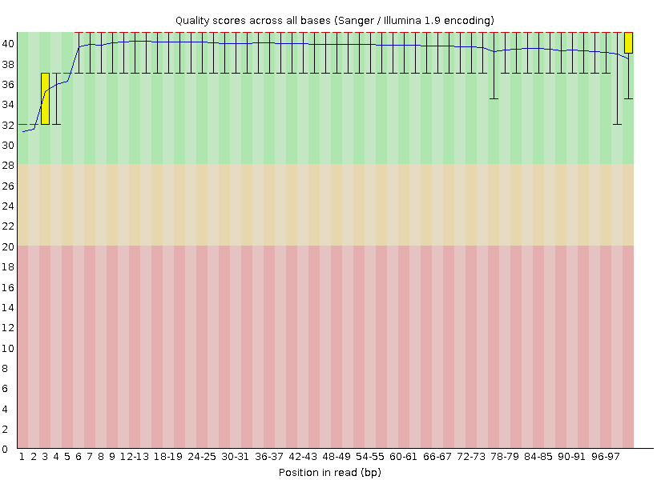

## Per tile sequence quality

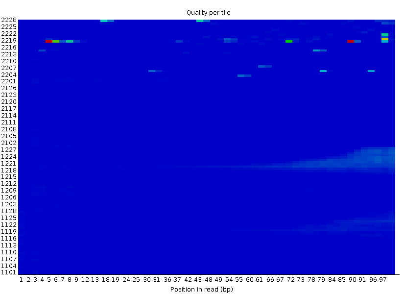

## Per sequence quality scores

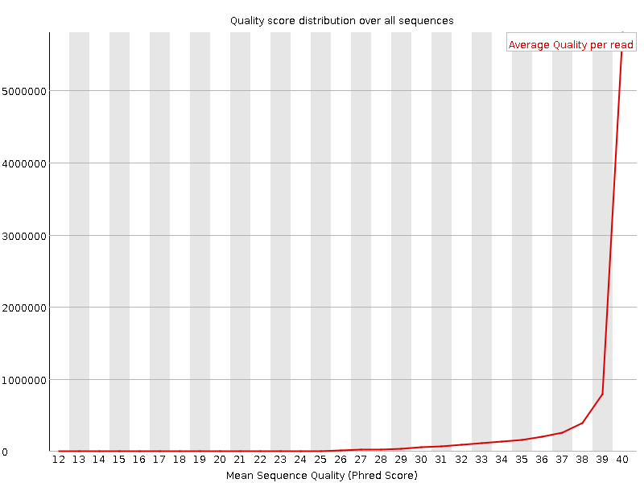

## Per base sequence content

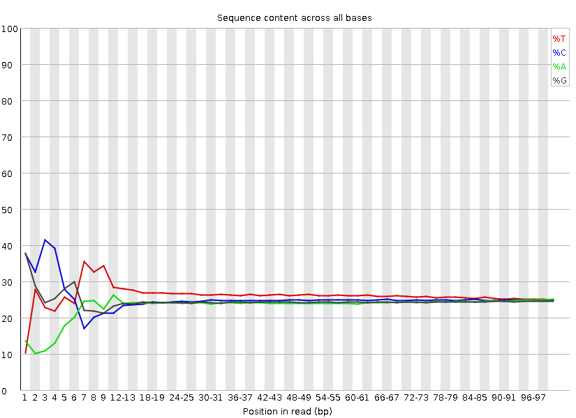

## Per sequence GC content

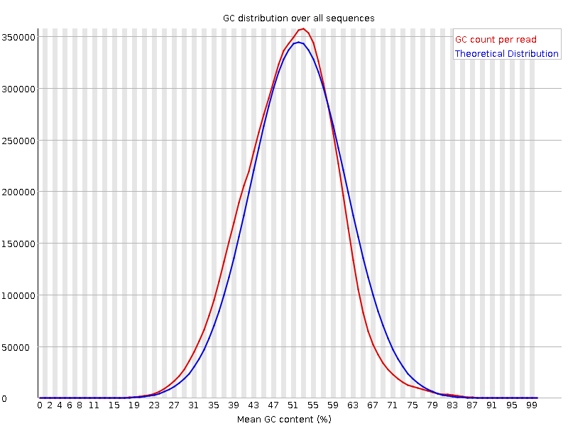

## Sequence Length Distribution

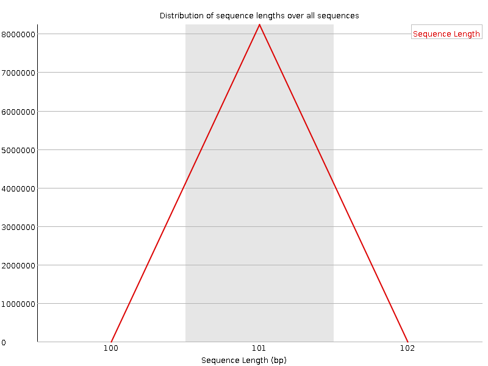

## Sequence Duplication Levels

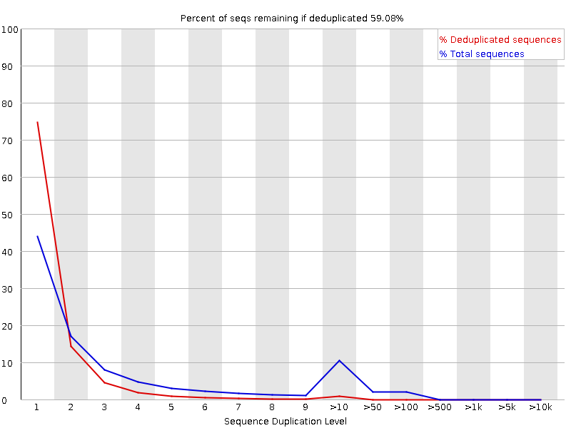

## Overrepresented sequences

| Sequence | Count | Percentage | Possible Source |
| --- | --- | --- | --- |
| GATCGGAAGAGCACACGTCTGAACTCCAGTCACACGATCAGATCTCGTAT | 12410 | 0.15069463426315122 | TruSeq Adapter, Index 15 (97% over 36bp) |

## Adapter Content

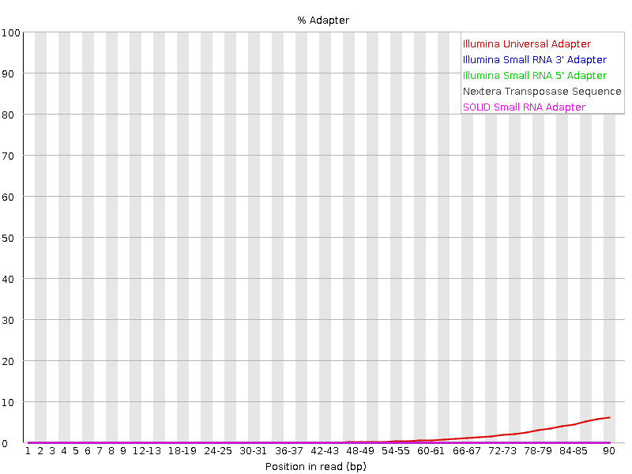

Produced by [FastQC](http://www.bioinformatics.babraham.ac.uk/projects/fastqc/) (version 0.11.9)

[figure not shown]